# Introduction to homework

Wei Feng

2022-12-07

This vignettes file is about all my homework answers.

## Question1

Use knitr to produce at least 3 examples(texts,figure,table)

### Answer1

Analyze the data set iris in R

1. We will show what the iris looks like.

```r
head(iris)
```

```
##   Sepal.Length Sepal.Width Petal.Length Petal.Width Species
## 1          5.1         3.5          1.4         0.2  setosa
## 2          4.9         3.0          1.4         0.2  setosa
## 3          4.7         3.2          1.3         0.2  setosa
## 4          4.6         3.1          1.5         0.2  setosa
## 5          5.0         3.6          1.4         0.2  setosa
## 6          5.4         3.9          1.7         0.4  setosa
```

```r
tail(iris)
```

```
##     Sepal.Length Sepal.Width Petal.Length Petal.Width   Species
## 145          6.7         3.3          5.7         2.5 virginica
## 146          6.7         3.0          5.2         2.3 virginica
## 147          6.3         2.5          5.0         1.9 virginica
## 148          6.5         3.0          5.2         2.0 virginica
## 149          6.2         3.4          5.4         2.3 virginica
## 150          5.9         3.0          5.1         1.8 virginica
```

From the table we can see that the iris is made up of five columns : Sepal Length, Sepal Width Length , Petal Width , Species . In order to have a preliminary understanding of the iris dataset , we can use ‘summary’ function.

```r
summary(iris)
```

```
##   Sepal.Length    Sepal.Width     Petal.Length    Petal.Width
##  Min.   :4.300   Min.   :2.000   Min.   :1.000   Min.   :0.100
##  1st Qu.:5.100   1st Qu.:2.800   1st Qu.:1.600   1st Qu.:0.300
##  Median :5.800   Median :3.000   Median :4.350   Median :1.300
##  Mean   :5.843   Mean   :3.057   Mean   :3.758   Mean   :1.199
##  3rd Qu.:6.400   3rd Qu.:3.300   3rd Qu.:5.100   3rd Qu.:1.800
##  Max.   :7.900   Max.   :4.400   Max.   :6.900   Max.   :2.500
##        Species
##  setosa    :50
##  versicolor:50
##  virginica :50
##
##
##
```

From the outcome , we can see the minimum value , maximum value , median , mean , quartile of each feature . Besides , we can also learn that there are three different species in iris dataset , setosa , versicolor , virginica . Each specie has the same sample size .

2. We want to draw a picture to show the relationship between petal length and petal width . We can use “ggplot2” to help us finish this job . If we want to show the density of the species in the picture , we can use “ggMarginal” funtion .

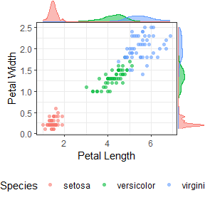

```r
# library
library(ggplot2)
library(ggExtra)

# classic plot
p <- ggplot(iris) +
  geom_point(aes(x = Petal.Length, y = Petal.Width, color = Species), alpha = 0.6, shape = 16) +
  theme_bw() +
  theme(legend.position = "bottom") +
  labs(x = "Petal Length", y = "Petal Width")
ggMarginal(p, type = "density", groupColour = TRUE, groupFill = TRUE)
```

3. If we want to use latex to generate a table , but we may not familiar with latex , we can use “xtable::xtable” to help us producing Latex code for a table.

```r
library(xtable)
xtable(tail(iris))
```

```
## % latex table generated in R 4.2.2 by xtable 1.8-4 package
## % Wed Dec  7 15:31:56 2022
## \begin{table}[ht]
## \centering
## \begin{tabular}{rrrrrl}
##   \hline
##  & Sepal.Length & Sepal.Width & Petal.Length & Petal.Width & Species \\
##   \hline
## 145 & 6.70 & 3.30 & 5.70 & 2.50 & virginica \\
##   146 & 6.70 & 3.00 & 5.20 & 2.30 & virginica \\
##   147 & 6.30 & 2.50 & 5.00 & 1.90 & virginica \\
##   148 & 6.50 & 3.00 & 5.20 & 2.00 & virginica \\
##   149 & 6.20 & 3.40 & 5.40 & 2.30 & virginica \\
##   150 & 5.90 & 3.00 & 5.10 & 1.80 & virginica \\
##    \hline
## \end{tabular}
## \end{table}
```

4. In addition , we can use knitr to output standard mathematical formulas . We will show some functions commonly used in deep learning below.

Activation function:

1.sigmoid function:
$$\operatorname{sigmoid}(x)=\frac{1}{1+\exp
(-x)}$$

2.tanh function:
$$\tanh (x)=\frac{1-\exp
(-2 x)}{1+\exp (-2 x)}$$

Loss function:

1. L2 loss:
   $$M S
   E=\frac{\sum_{i=1}^{n}\left(y_{i}-y_{i}^{p}\right)^{2}}{n}$$
2. Cross-Entropy Loss:
   $$\operatorname{Loss}=-\sum_{i=1}^{n} y_{i} \log
   y_{i}^{\prime}$$

## Question2

The $Pareto(a,b)$ distribution has cdf
$$F(x)=1-\left(\frac{b}{x}\right)^{a}, \quad
x \geq b>0, a>0$$
Derive the probability inverse transformation $F^{-1}(U)$ and use the inverse transform method to simulate a random sample with the $Pareto(2,2)$ distribution . Graph the density histogram of sample with the $Pareto(2,2)$ denisty superimposed for comparison .

### Answer2

The probability inverse transformation is
$$F^{-1}(U) =
\frac{b}{(1-u)^{\frac{1}{a}}}$$
If $X \sim Pareto(2,2)$ , then
$$F^{-1}(U)
= \frac{2}{(1-u)^{\frac{1}{2}}}$$
and the probability density function of X is
$$\begin{align*}
f(x) = &F^{'}(X)\\
=&(\frac{2}{x})^{3} ,\quad x \geq 2
\end{align*}$$
So we can use R to generate random numbers .

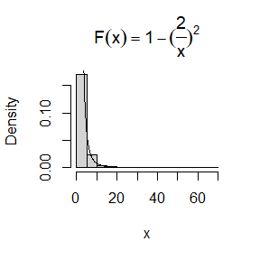

```r
set.seed(22092)
n<-1000
u<-runif(n)
x<-2/sqrt(1-u)
hist(x,prob =TRUE,main = expression(F(x)==1-(frac(2,x))^2))
y<-seq(min(x),max(x),length=n)
lines(y,(2/y)^3)
```

## Question3

Write a function to generate a random sample of size n from the $Beta(a,b)$ distribution by the acceptance-rejection method. Generate a random sample of size 1000 from the $Beta(3,2)$ distribution. Graph the histogram of the sample with the theoretical $Beta(3,2)$ density superimposed .

### Answer3

If $X \sim Beta(a,b)$ , then the probability density function of X is
$$f(x)=\frac{\Gamma(a+b)}{\Gamma(a) \Gamma(b)}
x^{a-1}(1-x)^{b-1}, \quad 0 \leq x \leq 1$$
Let $g(x)=1,\quad 0<x<1$ , our aim is to decide which c is better .
$$f^{'}(x)
=\frac{\Gamma(a+b)}{\Gamma(a)
\Gamma(b)}((a-1)x^{a-2}(1-x)^(b-1)-(b-1)x^{a-1}(1-x)^{b-2})$$
Let $f^{'}(x)=0$ , we can know that the maximum point of $f(x)$ is $\frac{a-1}{a+b-2}$ , so the maximum value of $f(x)$ is $f(\frac{a-1}{a+b-2}) = \frac{\Gamma(a+b)}{\Gamma(a) \Gamma(b)} (\frac{a-1}{a+b-2})^{a-1}(\frac{b-1}{a+b-2})^{b-1}$ . So we can Write a function to generate a random sample of size n from the $Beta(a,b)$ distribution .

```r
randomNumber_beta<-function(n,a,b){
  j<-k<-0
  y<-numeric(n)
  while(k<n){
    u<-runif(1)
    j<-j+1
    x<-runif(1)
    if(x^(a-1)*(1-x)^(b-1)>u*((a-1)/(a+b-2))^(a-1)*((b-1)/(a+b-2))^(b-1)){
      k<-k+1
      y[k]<-x
    }
  }
  return(y)
}
```

if $a=3,b=2,n=1000$,then we can use randomNumber_beta(1000,3,2) to generate 1000 samples .

```r
y<-randomNumber_beta(1000,3,2)
```

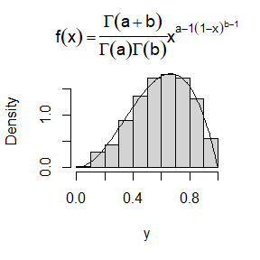

```r
hist(y,prob =TRUE,main = expression(f(x)==frac(Gamma(a+b),Gamma(a) *Gamma(b))* x^{a-1}(1-x)^{b-1}))
z<-seq(0,1,.01)
lines(x=z,y=dbeta(z,3,2))
```

Besides , we can use quantile-quantile plot to have a examination .

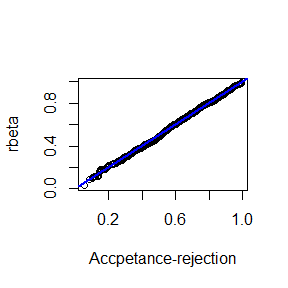

## Question4

Simulate a continuous Exponential-Gamma mixture . Suppose that the rate parameter has $Gamma(\gamma, \beta)$ distribution and $Y$ has $Exp(\Lambda)$ distribution . That is , $(Y \mid \Lambda=\lambda) \sim f_{Y}(y \mid \lambda)=\lambda e^{-\lambda y}$ . Generate 1000 random observations from this mixture with $\gamma = 4$ and $\beta = 2$ .

### Answer4

```r
r <- 4
beta <- 2
n <- 1e4
lambda <- rgamma(n,r,beta)
x <- rexp(n,lambda)
x[1:20]
```

```
##  [1] 1.276309901 0.116841680 0.001017113 0.304626217 0.632273924 0.351838333
##  [7] 0.353024127 1.373147601 0.102551330 0.536224108 0.234278669 0.124876367
## [13] 0.289358363 0.077905647 0.252145852 0.329071355 0.060640321 0.596236419
## [19] 0.271134916 0.290527046
```

## Question5

It can be shown that the mixture in Exercise 3.12 has a $Pareto$ distribution with cdf
$$F(y)=1-\left(\frac{\beta}{\beta+y}\right)^{r},
\quad y \geq 0$$
(This is an alternative parameterization of the $Pareto$ cdf given in Exercise 3.3) . Generate 1000 random observations from the mixture with $\gamma = 4$ and $\beta = 2$ . Compare the empirical and theoretical ($Pareto$) distributions by graphing the density histogram of the sample and superimposing the $Pareto$ density curve

### Answer5

$$\begin{align*}
P(Y\leq y)=&\int_{0}^{+\infty}P(Y\leq
y|\Lambda=\lambda)*f(\lambda)d\lambda\\
=&\int_{0}^{+\infty}(1- e^{-\lambda
y})*\frac{\beta^{\gamma}}{\Gamma(\gamma)}*\lambda^{\gamma-1}e^{-\beta
\lambda}d\lambda\\
=&1-\left(\frac{\beta}{\beta+y}\right)^{r}\\
\end{align*}$$

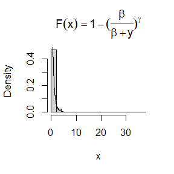

```r
r <- 4
beta <- 2
n <- 1e4
lambda <- rgamma(n,r,beta)
x <- rexp(n,lambda)
hist(x,probability = TRUE,main=expression(F(x)==1-(frac(beta,beta+y))^gamma))
y<-seq(min(x),max(x),length=n)
lines(y,64/(2+y)^5)
```

## Question6

- 1:
  - For $n=10^4,2\times10^4,4\times10^4,6\times10^4,8\times10^4$, apply the fast sorting algorithm to randomly permuted numbers of $1,\ldots,n$.
  - Calculate computation time averaged over 100 simulations, denoted by $a_n$.
  - Regress $a_n$ on $t_n:=n\log(n)$, and graphically show the results (scatter plot and regression line).

### Answer6

1. We need to write a function about fast sorting algorithm .

```r
quick_sort <- function(x){
  num<-length(x)
  if(num==0||num==1){
    return(x)
  }else{
    sentinel<-sample(1:num,1)#random pick one number
    a<-x[sentinel]
    y<-x[-sentinel]
    lower<-y[y<a]
    upper<-y[y>=a]
    return(c(quick_sort(lower),a,quick_sort(upper)))
  }
}
```

We can use “system.time” function to help us calculate computation time . The function has three return values: user,system,elapse . We use the first return value for comparison .

```r
i =1 #Fill the data in row i of the matrix
m = matrix(nrow =5,ncol = 100)
for (n in c(10^4,2*10^4,4*10^4,6*10^4,8*10^4)) {
  for ( j in 1:100) {
    test <- sample(1:n)
    m[i,j]<-system.time(quick_sort(test))[1]
  }
  i = i+1;
}
a_n<-rowMeans(m)
a_n
```

```
## [1] 0.0567 0.1235 0.2386 0.3404 0.4507
```

We will draw a scatter plot and regresssion line of $t_n$ and $a_n$.

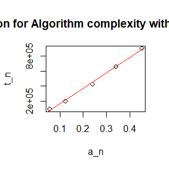

```r
t_n <- c(10^4,2*10^4,4*10^4,6*10^4,8*10^4)*log(c(10^4,2*10^4,4*10^4,6*10^4,8*10^4))
plot(a_n,t_n,main="Regression for Algorithm complexity with running time")
abline(lm(t_n~a_n),col='red')
```

From the picture , we can see that the 5 points are approximately in the regression line , so we can get a conclusion that the time complexity of quick sort is $O(nlog(n))$.

## Question7

5.6 In Example 5.7 the control variate approach was illustrated for Monte Carlo integration of
$$\theta =
\int_{0} ^{1} e^xdx.$$
Now consider the antithetic variate approch . Compute $Cov(e^u,e^{1-u})$ and $Var(e^u+e^{1-u})$ , where $U \sim Uniform(0,1)$ . What is the percent reduction in variance of $\hat \theta$ that can be achieved using antithetic variates(compared with simple MC)?

### Answer7

$$\begin{align*}
E(e^u) =& \int_{0} ^{1} e^udu
=e-1\\
E(e^{1-u}) =& \int_{0} ^{1} e^{1-u}du
=e-1 \\
E(e^{2u}) =& \int_{0} ^{1} e^{2u}du
=\frac{1}{2} (e^2-1)\\
E(e^{2-2u}) =& \int_{0} ^{1} e^{2-2u}du
=\frac{1}{2} (e^2-1)
\end{align*}$$

$$\begin{align*}
Cov(e^u,e^{1-u}) =& E(e^u-E(e^u))(e^{1-u}-E(e^{1-u}))\\
=& E(e^u-(e-1))(e^{1-u}-(1-u))\\
=& E(e-(e-1)(e^u+e^{1-u})+(e-1)^2)\\
=& e-(e-1)^2\\
\doteq& -0.2342106\\
Var(e^u+e^{1-u}) =& E(e^u+e^{1-u})^2-(E(e^u+e^{1-u}))^2\\
=& E(e^{2u}+e^{2-2u}+2e)-(2e-2)^2\\
=& -3e^2+10e-5\\
\doteq& 0.01564999
\end{align*}$$

We can use code to verify this result.

```r
x<-runif(10000)
cov <- cov(exp(x),exp(1-x))
var <- var(exp(x)+exp(1-x))
cov;var
```

```
## [1] -0.2358316
```

```
## [1] 0.01562349
```

If we use simple Monte Carlo approach with m replicate , the variance of the estimator is $\frac{Var(e^u)}{m}$ , where
$$Var(e^u) = E(e^{2U})-(E(e^u))^2=\frac{1}{2}
e^2+2e-\frac{3}{2} \doteq 0.2420351$$
So the percent reduction in variance of $\hat \theta$ is 100(1-0.01564999/2/0.2420356)=96.76701% .

## Question8

Refer to Exercise 5.6. Use a Monte Carlo simulation to estimate $\theta$ by the antithetic variate approach and by the simple Monte Carlo method. Compute an empirical estimate of the percent reduction in variance using the antithetic variate. Compare the result with the theoretical value from Exercise 5.6 .

### Answer8

The simple estimator is
$$\hat \theta =
\frac{1}{m} \sum_{j=1} ^{m} e^{U_j} , U_j \sim U(0,1)$$
The antithetic variable estimator is
$$\hat
\theta' = \frac{1}{m} \sum_{j=1} ^{m/2} (e^{U_j}+e^{(1-U_j)}) , U_j
\sim U(0,1)$$
Simple Monte Carlo method:

```r
m<-1e4
x<-runif(m)
theta.hat <-mean(exp(x))
theta.hat
```

```
## [1] 1.724172
```

Antithetic variate approach:

```r
u<-runif(m/2)
v<-1-u
u<-c(u,v)
g<-exp(u)
theta_hat<-mean(g)
theta_hat
```

```
## [1] 1.717025
```

We need to write a function integration method 1 and method 2, so that we can repeat the experiment to calculate the variance.

```r
MC.Phi <- function(R = 10000, antithetic = FALSE) {
  u <- runif(R/2)
  if (antithetic) v <- 1 - u else v <- runif(R/2)
  u <- c(u, v)
  g <-exp(u)
  theta<- mean(g)
  theta
}

m <- 1000
MC1 <- MC2 <- numeric(m)
x <- 1
for (i in 1:m) {
  MC1[i] <- MC.Phi(R = 1000, antithetic = FALSE)
  MC2[i] <- MC.Phi(R = 1000, antithetic = TRUE)
}
var(MC1);var(MC2);1-var(MC2)/var(MC1)
```

```
## [1] 0.0002568227
```

```
## [1] 7.849959e-06
```

```
## [1] 0.9694343
```

## Question9

Find two importance function $f_1$ and $f_2$ that are supported on $(1,\infty)$ and are ‘close’ to
$$g(x) =
\frac{x^2}{\sqrt{2\pi}}e^{-\frac{x^2}{2}} \quad ,\quad x>1$$
Which of your two importance function should produce the smaller variance in estimating
$$\int_{1}^{\infty}
\frac{x^2}{\sqrt{2\pi}}e^{-\frac{x^2}{2}}dx$$
by importance sampling? Explain.

### Answer9

To calculate this integral, we can try to change the upper and lower bounds of the integral .

$$\begin{align*}
\int_1 ^{\infty}\frac{x^2}{\sqrt{2\pi}}e^{-\frac{x^2}{2}} dx =&
\int_0 ^{\infty}\frac{x^2}{\sqrt{2\pi}}e^{-\frac{x^2}{2}} dx - \int_0
^1\frac{x^2}{\sqrt{2\pi}}e^{-\frac{x^2}{2}} dx \\
=& \int_0 ^{\infty}\frac{-x}{\sqrt{2\pi}} de^{-\frac{x^2}{2}} -
\int_0 ^1\frac{x^2}{\sqrt{2\pi}}e^{-\frac{x^2}{2}} dx \\
=& -\frac{x}{\sqrt(2\pi)}*e^{\frac{-x^2}{2}}|_0 ^{+\infty} + \int_0
^{\infty}\frac{x^2}{\sqrt{2\pi}}e^{-\frac{x^2}{2}} dx - \int_0
^1\frac{x^2}{\sqrt{2\pi}}e^{-\frac{x^2}{2}} dx \\
=& \frac{1}{2} - \int_0 ^1\frac{x^2}{\sqrt{2\pi}}e^{-\frac{x^2}{2}}
dx
\end{align*}$$
So our goal is to calculate the following integral:
$$\int_0
^1\frac{x^2}{\sqrt{2\pi}}e^{-\frac{x^2}{2}}$$

I choose 3 importance functions :
$$f_1(x)=\frac{4}{\pi *(1+x^2)} \quad ,\quad
0<x<1$$
$$f_2(x)=e^{-x} \quad
,\quad x>0$$
$$f_3(x)=\frac{x}{1-e^{-\frac12}}e^{-\frac{x^2}{2}} \quad ,\quad
0<x<1$$
First, I will draw the pictures of these three functions to observe the trend of the density function.

[figure not shown]

```r
x <- seq(0, 1, 0.01)
w <- 2

g <- x^2*exp(-x^2/2) / sqrt(2*pi)
f1 <- 4 / ((1 + x^2) * pi)
f2 <- exp(-x)
f3 <- x*exp(-x^2/2)/(1-exp(-1/2))
gs <- c(expression(g(x)==x^2*e^{-x^2/2}/sqrt(2*pi)),
           expression(f[1](x)==4/((1+x^2)*pi)),
            expression(f[2](x)==e^{-x}),
            expression(f[3](x)==x*e^{-x^2}/(1-e^{-1/2}))
   )
    #for color change lty to col
par(mfrow=c(1,1))
    #figure (a)
plot(x, g, type = "l", ylab = "",
         ylim = c(0,2.5), lwd = w,col=1,main='dentisy fucntion')
    lines(x, f1, lty = 2, lwd = w,col=2)
    lines(x, f2, lty = 3, lwd = w,col=3)
    lines(x, f3, lty = 4, lwd = w,col=4)
    legend("topleft", legend = gs,
           lty = 1:4, lwd = w, inset = 0.02,col=1:4)
```

Next , I draw the trend of the functions: $\frac{g}{f_1},\frac{g}{f_2},\frac{g}{f_3}$

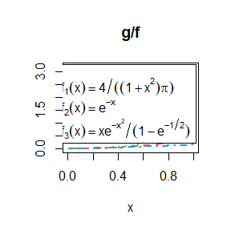

```r
plot(x, g/f1, type = "l", ylab = "",
        ylim = c(0,3.2), lwd = w, lty=2,col=2 ,main='g/f')
lines(x, g/f2, lty = 3, lwd = w,col=3)
lines(x, g/f3, lty = 4, lwd = w,col=4)
legend("topright", legend = gs[-1],
           lty = 2:4, lwd = w, inset = 0.02,col=2:4)
```

It’s time to generate the random number and compute the integration.

```r
library(knitr)
m <- 1e4
est <- sd <- numeric(3)
g <- function(x) {
  exp(-x^2/2)*x^2/sqrt(2*pi) * (x > 0) * (x < 1)
  }
u <- runif(m) #f1, inverse transform method
x <- tan(pi * u / 4)
fg <- g(x) / (4 / ((1 + x^2) * pi))
est[1] <- mean(fg)
sd[1] <- sd(fg)
x <- rexp(m, 1) #using f2
fg <- g(x) / exp(-x)
est[2] <- mean(fg)
sd[2] <- sd(fg)
u <- runif(m) #f3, inverse transform method
x <-  sqrt(-2*log(1-(1-exp(-1/2))*u))
fg <- g(x) / (x*exp(-x^2/2))*(1-exp(-1/2))
est[3] <- mean(fg)
sd[3] <- sd(fg)
```

We output the results in the form of a table.

```r
res <- rbind(est=round(est,3), sd=round(sd,3))
colnames(res) <- paste0('f',1:3)
knitr::kable(res, format = "markdown",align='c')
```

|  | f1 | f2 | f3 |
| --- | --- | --- | --- |
| est | 0.099 | 0.099 | 0.099 |
| sd | 0.105 | 0.161 | 0.037 |

So the integral is :
$$\int_1
^{\infty}\frac{x^2}{\sqrt{2\pi}}e^{-\frac{x^2}{2}} dx= \frac{1}{2} -
\int_0 ^1\frac{x^2}{\sqrt{2\pi}}e^{-\frac{x^2}{2}} dx = \frac12 - 0.099
= 0.401$$

From the table , we can see that $f_3(x)=\frac{x}{1-e^{-\frac12}}e^{-\frac{x^2}{2}} \quad ,\quad 0<x<1$ has the minimum variance . As shown in Figure g/f, the $\frac{g(x)}{f_3(x)}$ approximation is a constant, so the variance is minimum.

## Question10

Obtain the stratified importance sampling estimate in Example 5.13 and compare it with the result of Example 5.10.

### Answer10

In Example 5.10 our best result was obtained with importance function $f_3(x) =\frac{e^{−x}}{1 − e^{-1}}, 0 <x< 1.$ From 10000 replicates we obtained the estimate$\hat\theta = 0.5257801$ and an estimated standard error 0.0970314. Now divide the interval (0,1) into five subintervals, $(\frac{j}{5},\frac{j+1}{5})$, j = 0, 1,…, 4.

In order for $f_3(x)$ to be a density function in the interval $(\frac{j}{5},\frac{j+1}{5})$, we need to multiply the term c.
$$\int_{\frac{j}{5}}^{\frac{j+1}{5}} c
\frac{e^{-x}}{1-e^{-1}}dx=1$$
So
$$c =
\frac{1-e^{-1}}{e^{-\frac{j+1}{5}}-e^{-\frac{j}{5}}}$$

Then on the $j^{th}$ subinterval variables are generated from the density
$$\frac{e^{-x}}{e^{-\frac{j+1}{5}}-e^{-\frac{j}{5}}} \quad , \quad
\frac{j}{5}<x<\frac{j+1}{5}$$
$$\begin{aligned}
\int_{0}^{1} e^{-x} /\left(1+x^{2}\right) d x &=\sum_{j=1}^{k}
\int_{\frac{j-1}{k}}^{\frac{j}{k}} e^{-x} /\left(1+x^{2}\right) d x \\
&=\sum_{j=1}^{k} \int_{\frac{j-1}{k}}^{\frac{j}{k}} \frac{e^{-x}
/\left(1+x^{2}\right)}{e^{-x}/{(e^{-\frac{j}{5}}-e^{-\frac{j-1}{5}}})}
*\frac{e^{-x}}{e^{-\frac{j}{5}}-e^{-\frac{j-1}{5}}}d x \\
&=\sum_{j=1}^{k} \int_{\frac{j-1}{k}}^{\frac{j}{k}}
\frac{e^{-\frac{j}{5}}-e^{-\frac{j-1}{5}}}{1+x^2}
*\frac{e^{-x}}{e^{-\frac{j}{5}}-e^{-\frac{j-1}{5}}}d x \\
&= \sum_{j=1}^{k} E
\frac{e^{-\frac{j}{5}}-e^{-\frac{j-1}{5}}}{1+X_{i}^2}\\
& where X_{i}\sim
\frac{e^{-x}}{e^{-\frac{j}{5}}-e^{-\frac{j-1}{5}}}.
\end{aligned}$$

```r
M<-10000
k<-5
r<-M/k
N<-50
T2<-numeric(k)
est<-rep(0,N)
g<-function(x){1/(1+x^2)}
for (i in 1:N) {
  for (j in 1:k) {
    U<-runif(M/k)
    a<- exp(-(j-1)/k)-exp(-j/k)
    x<- -log(exp(-(j-1)/5)-a*U)
    T2[j]<-mean(g(x)*a)
  }
  est[i] <- sum(T2)
}
round(mean(est),4)
```

```
## [1] 0.5248
```

```r
round(sd(est),5)
```

```
## [1] 0.00016
```

From the result we can see that the estimation of $\theta$ is 0.5248, and an estimated standard error is 0.00016,which is much smaller than 0.0970314.

## Question11

6.4 Suppose that $X_1,...,X_n$ are a random sample from a lognormal distribution with unkonwn parameters.Construct a 95% confidence interval for the parameter $\mu$.Use a Monte Carlo method to obtain an empirical estimate of the confidence level.

### Answer11

Because $X_1,...X_n \sim LN(\mu,\sigma^2)$, then $log(X_1),...,log(X_n)\sim N(\mu,\sigma^2)$. So
$$\frac{\frac1n\sum_{i=1}^n log(X_i)-\mu}{\sigma /
\sqrt{n}} \sim N(0,1)$$
Let $S^2$ is the sample variance,then
$$\frac{(n-1) S^{2}}{\sigma^{2}} \sim
\chi^{2}(n-1).$$
Thus
$$\frac{\frac1n\sum_{i=1}^n log(X_i)-\mu}{S /
\sqrt{n}} \sim t(n-1)$$

So the $100(1-\alpha)\%$ confidence intervals is given by
$$(\frac1n\sum_{i=1}^n
log(X_i)+\frac{S}{\sqrt{n}}t_{\frac{\alpha}{2}}(n-1),\frac1n\sum_{i=1}^n
log(X_i)-\frac{S}{\sqrt{n}}t_{\frac{\alpha}{2}}(n-1))$$

Now we assume that the sample size n = 20 from a Normal(2,4) distribution.The calculation of 95% confidence of is shown below.

```r
set.seed(20221009)
remove(list=ls()) # clear up memory
n<-20
alpha<-0.05
m<-10000
LCL <-UCL<- numeric(m)
for (i in 1:m) {
  x<-rnorm(n,mean = 2,sd=2)
  LCL[i]<-sum(x)/n +sd(x)*qt(alpha/2,df=n-1)/sqrt(n)
  UCL[i]<-sum(x)/n -sd(x)*qt(alpha/2,df=n-1)/sqrt(n)
}
sum(LCL<2 & UCL>2)
```

```
## [1] 9510
```

```r
mean(LCL<2 & UCL>2)
```

```
## [1] 0.951
```

The result is that 9510 intervals satisfied(LCL<2<UCL),so the empirical confidence level is 95.1% in this experiment,which is close to the theoretical value , 95%.

## Question12

Refer to Example 6.16.Repeat the simulation , but also compute the F test of equal variance ,at significance level $\hat \alpha \doteq 0.055$.Compare the power of the Count Five test and F test for small ,medium,and large sample size.(Recall that the F test is not applicable for non-normal distribution).

### Answer12

Firstly,we write a function about Count Five test.

```r
count5test <- function(x,y){
  X<-x-mean(x)
  Y<-y-mean(y)
  outx <- sum(X>max(Y)) + sum(X<min(Y))
  outy <- sum(Y>max(X)) + sum(Y<min(X))
  return (as.integer(max(c(outx,outy))>5))
}
```

Then , I choose 6 sample sizes:20,100,500,1000,5000,10000.

```r
sigma1 <-1
sigma2 <-1.5
m<-c(20,100,500,1000,5000,10000)
power<-FResult<-numeric(length(m))
z <- 1
for (i in m) {
  test1<-numeric(10000)
  test2<-numeric(10000)
  for (j in 1:10000) {
    x<-rnorm(i,0,sigma1)
    y<-rnorm(i,0,sigma2)
    test1[j] <- count5test(x,y)
    x<-x-mean(x)
    y<- y-mean(y)
    test2[j] <- var.test(x,y)$p.value<0.055
  }
  power[z]<-mean(test1)
  FResult[z]<-mean(test2)
  z <- z+1
}
res <- rbind(size=m,count5Test=power,Ftest=FResult)
res
```

```
##               [,1]     [,2]     [,3]      [,4]      [,5]  [,6]
## size       20.0000 100.0000 500.0000 1000.0000 5000.0000 10000
## count5Test  0.3100   0.8461   0.9914    0.9977    0.9998     1
## Ftest       0.4139   0.9799   1.0000    1.0000    1.0000     1
```

## Question13

If we obtain the powers for two methods under a particular simulation setting with 10,000 experiments: say, 0.651 for one method and 0.676 for another method. Can we say the powers are different at 0.05 level? (1) What is the corresponding hypothesis test problem? (2) Which test can we use? Z-test, two-sample t-test, paired-t test or McNemar test? Why? (3) Please provide the least necessary information for hypothesis testing.

### Answer13

We can’t say the powers are different at 0.05 level.

Denote the power of the two test by $p_1$ and $p_2$, then the corresponding hypothesis test problem is
$$H_0:p_2-p_1=0\leftrightarrow H_1:p_2-p_1\neq 0.$$
Now from the simulation we obtain that $\hat p_1=0.651$ and $\hat p_2=0.676$, where the number of trials is $n=10000$.

Naturally we may assume that the $10000$ experiments are independent. However, in each experiment, the results of the two tests are based on the same data and parameters, thus they are not independent with each other. Namely, we have obtained $10000$ paired data in the simulation.

Consequently, we cannot use two-sample t-test and Z-test (the large sample version of two-sample t-test), because the two samples corresponding to the two tests are not independent. Unfortunately, if we want to apply paired t-test or McNemar test (an equivalent of paired t-test for binary response data), the result of each experiment, namely, whether the two tests reject or accept $H_0$, is required.

In conclusion, we can use paired t-test or McNemar test provided the result of each experiment. That means we cannot say the powers are different at $0.05$ level if we only know that $\hat p_1=0.651$ and $\hat p_2=0.676$ with size $n=10000$. Note that it is more complicated than testing the equivalence of type-I error, since the **real distribution of the data is unknown** under the alternative hypothesis!

## Question14

7.4 Refer to air-conditioning data set aircondit provided in the boot package. The 12 observations are the times in hours between failures of air-conditioning equipment:
$$3, 5, 7, 18,
43, 85, 91, 98, 100, 130, 230, 487.$$
Assume that the times between failures follow an exponential model Exp().Obtain the MLE of the hazard rate and use bootstrap to estimate the bias and standard error of the estimate.

### Answer14

If $X_1,...X_n$ is the samples from an exponential model EXP(),then the joint probability distribution function is:
$$\begin{aligned}
f(x_1,...x_n) =&\prod \limits_{i=0}^n \lambda*e^{-\lambda x_i} \\
=&\lambda^n e^{-\sum_{i=0} ^{n} \lambda x_i}
\end{aligned}$$

Then the log likelihood function is
$$L(\lambda;x_1,...x_n) = nlog\lambda - \sum_{i=0}
^{n} \lambda x_i$$

Let $\frac{\partial}{\partial \lambda}L(\lambda;x_1,...x_n)=0$ , we can know that the MLE of $\lambda$ is
$$\hat \lambda = \frac{1}{\bar x} \quad,$$
where $\bar x$ is the mean of the sample.

```r
remove(list = ls())
dt <- c(3, 5, 7, 18, 43, 85, 91, 98, 100, 130, 230, 487)
xbar <- mean(dt)
lambda <- 1/xbar
lambda
```

```
## [1] 0.00925212
```

From the result of the R code ,we know that $\bar x = 108.0833$ , so $\hat \lambda =\frac{1}{\bar x} = 0.00925212$

```r
bootstrap1 <- function(x){
  B<- 1e4
  set.seed(20221014)
  lambdaStar <- numeric(B)
  for (b in 1:B) {
    xstar<-sample(x,replace = TRUE)
    lambdaStar[b] <- 1/mean(xstar)
  }
  return(lambdaStar)
}

lambdaStar <- bootstrap1(dt)
round(c(bias = mean(lambdaStar)-lambda,se.boot = sd(lambdaStar)),3)
```

```
##    bias se.boot
##   0.001   0.004
```

So the bias of the estimate is 0.001, standard error of the estimate is 0.004.

## Question15

Refer to Exercise 7.4. Compute 95% bootstrap confidence intervals for the mean time between failures 1/λ by the standard normal, basic, percentile, and BCa methods. Compare the intervals and explain why they may differ.

### Answer15

```r
library(boot)
lambda.boot <- function(dat,ind){
  1/mean(dat[ind])
}
boot.obj <- boot(dt,statistic=lambda.boot,R=2000)
print(boot.ci(boot.obj,
type = c("basic", "norm", "perc",'bca')))
```

```
## BOOTSTRAP CONFIDENCE INTERVAL CALCULATIONS
## Based on 2000 bootstrap replicates
##
## CALL :
## boot.ci(boot.out = boot.obj, type = c("basic", "norm", "perc",
##     "bca"))
##
## Intervals :
## Level      Normal              Basic
## 95%   (-0.0007,  0.0166 )   (-0.0034,  0.0132 )
##
## Level     Percentile            BCa
## 95%   ( 0.0053,  0.0219 )   ( 0.0046,  0.0188 )
## Calculations and Intervals on Original Scale
```

From the result we can see that the percentile intervals and BCa intervals are quite different from normal and basic interval. Inorder to know why , we fist draw the histogram of the data.

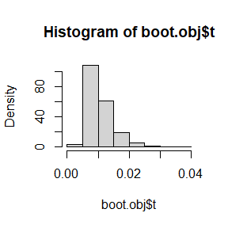

```r
hist(boot.obj$t,probability = TRUE)
```

From the picture , we can know that the sampling distribution of $\frac{1}{\bar x}$is not close to normal distribution . When the sampling distribution of the statistic is approximately normal,the percentile intervals and BCa intervals will agree with the normal interval.

## Question16

Conduct a Monte Carlo study to estimate the coverage probabilities of the standard normal bootstrap confidence interval, the basic bootstrap confidence interval, and the percentile confidence interval. Sample from a normal population and check the empirical coverage rates for the sample mean. Find the proportion of times that the confidence intervals miss on the left, and the porportion of times that the confidence intervals miss on the right.

### Answer16

```r
rm(list = ls())

skewness <- function(x,i) {
  #computes the sample skewness coeff.
  x_bar <- mean(x[i])
  x_bar
}

Sample3 <- function(n, mea, sd){
  samp <- rnorm(n, mea, sd)
  samp
}

Analysis3 <- function(m, func, Rr, n, mea, sd){
  library(boot)
  nornorm <- matrix(0, m, 2)
  norbasi <- matrix(0, m, 2)
  norperc <- matrix(0, m, 2)
  for (i in 1:m) {
    Samp <- Sample3(n, mea, sd)
    Skew <- boot(Samp, statistic = func, R=Rr)
    Nor <- boot.ci(Skew, type=c("norm","basic","perc"))
    nornorm[i,] <- Nor$norm[2:3]
    norbasi[i,] <- Nor$basic[4:5]
    norperc[i,] <- Nor$percent[4:5]
  }
  #Calculate the coverage probability of a normal distribution
  norm <- mean(nornorm[,1] <= s & nornorm[,2] >= s)
  basi <- mean(norbasi[,1] <= s & norbasi[,2] >= s)
  perc <- mean(norperc[,1] <= s & norperc[,2] >= s)
  #Calculate the probability of the left side of the normal distribution
  normleft <- mean(nornorm[,1] >= s )
  basileft <- mean(norbasi[,1] >= s )
  percleft <- mean(norperc[,1] >= s )
  #Calculate the right side probability of a normal distribution
  normright <- mean(nornorm[,2] <= s )
  basiright <- mean(norbasi[,2] <= s )
  percright <- mean(norperc[,2] <= s )
  analyresu <- c(norm, basi, perc, normleft, basileft, percleft, normright, basiright, percright)
  analyresu
}

Result3 <- function(sd, analyresu){
  dnam <- paste("N ( 0 ,", as.character(sd^2),")",seq="")
  Distribution <- c(dnam)
  Type <- c("basic", "norm", "perc")
  Left <- analyresu[4:6]
  Right <- analyresu[7:9]
  P.coverage <- analyresu[1:3]
  result <- data.frame(Distribution, Type, Left, Right, P.coverage)
  result
}
```

```r
s <- 0
n <- 20
m <- 1000
R <- 1000

mea <- 0
sd <- 3


set.seed(1234)
library(boot)

Analyresu <- Analysis3(m, skewness, R, n, mea, sd)
Resu <- Result3(sd, Analyresu)

knitr::kable (Resu, align="c")
```

| Distribution | Type | Left | Right | P.coverage |
| --- | --- | --- | --- | --- |
| N ( 0 , 9 ) | basic | 0.037 | 0.026 | 0.937 |
| N ( 0 , 9 ) | norm | 0.032 | 0.025 | 0.943 |
| N ( 0 , 9 ) | perc | 0.035 | 0.027 | 0.938 |

## Question17

Refer to Exercise 7.7.Obtain the jackknife estimate of bias and standard error of $\hat \theta$.

### Answer17

Denote $\hat\theta_{(i)}=\hat\theta(x_1,\ldots,x_{i-1},x_{i+1},\ldots,x_n)$. An unbiased estimate of the bias $E(\hat\theta)-\theta_0$ is
$$(n-1)(\bar{\hat\theta}_{(\cdot)}-\hat\theta)$$
An estimate of $se(\hat \theta)$ is
$$\sqrt{\widehat{var}(\hat\theta)} = \sqrt{
\frac{n-1}n\sum_{i=1}^n(\hat\theta_{(i)}-\bar{\hat\theta}_{(\cdot)})^2}$$

First we should calculate the sample variance , and then calculate the eigenvalues of $\hat\sum$. So the sample estimate is
$$\hat\theta =
\frac{\hat\lambda_1}{\sum_{j=1}^5 \hat\lambda_j}$$

```r
remove(list = ls())
thetaTrue <- function(x){
  sigma <- cov(x)
  ei <- eigen(sigma)
  lambda <- ei$values[order(-(ei$values))]
  lambda[1]/sum(lambda)
}
```

```r
jack <- function(x,theta.hat,n){
  for (i in 1:n) {
    x.jack <- scor[-i,]
    theta.hat[i] <- thetaTrue(x.jack)
  }
  theta.hat
}
```

```r
library(bootstrap)
n <- length(scor[,1])
theta.hat <- numeric(n)
theta <- thetaTrue(scor)
theta.hat <- jack(scor,theta.hat,n)
bias.jack <- (n-1)*(mean(theta.hat-theta))
se.jack <- sqrt((n-1)*mean((theta.hat-theta)^2))
round(c(original.theta = theta,bias.jack = bias.jack,se.jack = se.jack),4)
```

```
## original.theta      bias.jack        se.jack
##         0.6191         0.0011         0.0496
```

## Question18

7.11 In Example 7.18, leave-one-out (n-fold) cross validation was used to select the best fitting model. Use leave-two-out cross validation to compare the models.

### Answer18

1. Linear: $Y=\beta_{0}+\beta_{1} X+\varepsilon$ .
2. Quadratic: $Y=\beta_{0}+\beta_{1} X+\beta_{2} X^{2}+\varepsilon$ .
3. Exponential: $\log (Y)=\log \left(\beta_{0}\right)+\beta_{1} X+\varepsilon$ .
4. Log-Log: $\log (Y)=\beta_{0}+\beta_{1} \log (X)+\varepsilon$ .

First , I write a function to calculate the error of the four models.

```r
remove(list=ls())
e <- function(n,data1,data2){
  e1 <- e2 <- e3 <- e4 <- matrix(0,nrow=n*(n-1)/2,ncol = 2)
  k =1
  for (i in 1:n) {
    j = i+1
    while (j<=n) {
       y<- data1[c(-i,-j)]
       x<- data2[c(-i,-j)]

       J1 <- lm(y~x)
       yhat1_i <- J1$coef[1] + J1$coef[2] * data2[i]
       yhat1_j <- J1$coef[1] + J1$coef[2] * data2[j]
       e1[k,1] <- data1[i] - yhat1_i
       e1[k,2] <- data1[j] - yhat1_j

       J2 <- lm(y ~ x + I(x^2))
       yhat2_i <- J2$coef[1] + J2$coef[2] * data2[i] +J2$coef[3] * data2[i]^2
       yhat2_j <- J2$coef[1] + J2$coef[2] * data2[j] +J2$coef[3] * data2[j]^2
       e2[k,1] <- data1[i] - yhat2_i
       e2[k,2] <- data1[j] - yhat2_j

       J3 <- lm(log(y) ~ x)
       logyhat3_i <- J3$coef[1] + J3$coef[2] * data2[i]
       logyhat3_j <- J3$coef[1] + J3$coef[2] * data2[j]
       yhat3_i <- exp(logyhat3_i)
       yhat3_j <- exp(logyhat3_j)
       e3[k,1] <- data1[i] - yhat3_i
       e3[k,2] <- data1[j] - yhat3_j

       J4 <- lm(log(y) ~ log(x))
       logyhat4_i <- J4$coef[1] + J4$coef[2] * log(data2[i])
       logyhat4_j <- J4$coef[1] + J4$coef[2] * log(data2[j])
       yhat4_i <- exp(logyhat4_i)
       yhat4_j <- exp(logyhat4_j)
       e4[k,1] <- data1[i] - yhat4_i
       e4[k,2] <- data1[j] - yhat4_j

       k <- k+1
       j <- j+1
    }
  }
  return (list(e1=e1,e2=e2,e3=e3,e4=e4,J1=J1,J2=J2,J3=J3,J4=J4))
}
```

```r
library(DAAG)
attach(ironslag)
n<- length(magnetic)
err <- e(n,magnetic,chemical)
e1 <- err$e1
e2 <- err$e2
e3 <- err$e3
e4 <- err$e4
c(mean(e1^2),mean(e2^2),mean(e3^2),mean(e4^2))
```

```
## [1] 19.57227 17.87018 18.45491 20.46718
```

```r
detach(ironslag)
```

From the result , we can know that the quadratic model would be the best fit for the data under the prediction error criterion .

```r
err$J2
```

```
##
## Call:
## lm(formula = y ~ x + I(x^2))
##
## Coefficients:
## (Intercept)            x       I(x^2)
##    25.22190     -1.43158      0.05408
```

## Question19

8.2 Implement the bivariate Spearman rank correlation test for independence [255] as a permutation test. The Spearman rank correlation test statistic can be obtained from function cor with method = “spearman”. Compare the achieved significance level of the permutation test with the p-value reported by cor.test on the same samples.

### Answer19

```r
remove(list = ls())
x <- c(2,-2,-13,8,9,6)
y <- c(0,-1,-4,20,9,4)
cor.test(x,y,method = 'spearman')
```

```
##
##  Spearman's rank correlation rho
##
## data:  x and y
## S = 2, p-value = 0.01667
## alternative hypothesis: true rho is not equal to 0
## sample estimates:
##       rho
## 0.9428571
```

```r
rankx<-rank(x)
ranky<-rank(y)
pearson <- cor(x,y)
spearman <- cor(rankx,ranky)
N<-100000
rho_per <- rep(0,N)
for (i in 1:N) {
  x_per<-sample(x)
  rankx_per<- rank(x_per)
  y_per<-sample(y)
  ranky_per<-rank(y_per)
  rho_per[i] <- cor(rankx_per,ranky_per)
}
mean(abs(rho_per)>=abs(spearman))
```

```
## [1] 0.01652
```

## Question20

9.4 Implement a random walk Metropolis sampler for generating the standard Laplace distribution (see Exercise 3.2). For the increment, simulate from a normal distribution. Compare the chains generated when different variances are used for the proposal distribution. Also, compute the acceptance rates of each chain.

### Answer20

The density of the standard Laplace distribution is
$$f(x) = \frac1 2 e^{-|x|} \quad ,x \in
\mathbb{R}$$
1) Set the proposal pdf g(X) to be the density of normal distribution N(X,sigma).
2) set X_0 = 5
3) Repeat for i =2,3,…,N:
(a) Generate Y from N($ X_{i-1}$,sigma)
(b) Generate U from Uniform(0,1)
(c) Computer $\alpha\left(X_{i-1}, Y\right)=\frac{f(Y) g\left(X_{i-1} \mid Y\right)}{f\left(X_{i-1}\right) g\left(Y \mid X_{i-1}\right)}$ . Since we use random walk Metropolis sampler , then $g(X_{i-1} \mid Y) = g(Y \mid X_{i-1}) = g((Y-X_{i-1})^2)$ . So $\alpha(X_{i-1},Y) = \frac{f(Y)}{f(X_{i-1})}$. If $U \leq \alpha\left(X_{i-1}, Y\right)$ accept Y and set $X_{i}=Y$ ; otherwise set $X_{i}=X_{i-1}$ .
(d) Increment i.

First , I write a function to realize the random walk metropolis sampler.

```r
randomWalk <- function(sigma,x0,N){
  x <- numeric(N)
  x[1] <- x0
  u <- runif(N)
  k <- 0
  for (i in 2:N) {
    y <- rnorm(1,x[i-1],sigma)
    if(u[i]<=((0.5*exp(-abs(y)))/(0.5*exp(-abs(x[i-1]))))){
      x[i] <- y
    }else{
      x[i] <- x[i-1]
      k <- k+1
    }
  }
  return(list(x=x,k=k))
}
```

Then I choose six different sigma:0.05,0.50,2.00,5.00,10.00,20.00 .

```r
set.seed(22092)
N <- 2000
sigma <- c(0.05,0.50,2.00,5.00,10.00,20.00)
x0 <- 5
rw1 <- randomWalk(sigma[1],x0,N)
rw2 <- randomWalk(sigma[2],x0,N)
rw3 <- randomWalk(sigma[3],x0,N)
rw4 <- randomWalk(sigma[4],x0,N)
rw5 <- randomWalk(sigma[5],x0,N)
rw6 <- randomWalk(sigma[6],x0,N)
accept.rate <- c(1-(rw1$k)/N, 1-(rw2$k)/N, 1-(rw3$k)/N, 1-(rw4$k)/N,1-(rw5$k)/N,1-(rw6$k)/N)
accept <- data.frame(sigma = sigma, no.reject=c(rw1$k, rw2$k, rw3$k, rw4$k,rw5$k,rw6$k), accept.rate = accept.rate)
knitr::kable(accept)
```

| sigma | no.reject | accept.rate |
| --- | --- | --- |
| 0.05 | 40 | 0.9800 |
| 0.50 | 341 | 0.8295 |
| 2.00 | 930 | 0.5350 |
| 5.00 | 1421 | 0.2895 |
| 10.00 | 1664 | 0.1680 |
| 20.00 | 1824 | 0.0880 |

From the table , we can see that the rate of acceptance decreases as the variance of the Normal distribution increase.

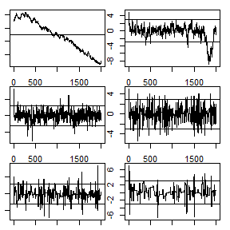

```r
 par(mar=c(1,1,1,1))
 par(mfrow=c(3,2))  #display 4 graphs together
    refline <- c(log(0.05), -log(0.05))
    rw <- cbind(rw1$x, rw2$x, rw3$x,  rw4$x,rw5$x,rw6$x)
    for (j in 1:6) {
        plot(rw[,j], type="l",
             xlab=bquote(sigma == .(round(sigma[j],3))),
             ylab="X", ylim=range(rw[,j]))
        abline(h=refline)
    }
```

```r
    par(mar=c(1,1,1,1))
    par(mfrow=c(1,1))
```

Use Germal-Rubin method to monitor convergence.

```r
Gelman.Rubin <- function(psi) {
  #psi[i,j] is the statistic psi(X[i,1:j]) for chain in i-th row of X
  psi <- as.matrix(psi)
  n <- ncol(psi)
  k <- nrow(psi)

  psi.means <- rowMeans(psi)  #row means
  B <-  n * var(psi.means)   #between variance est
  psi.w <- apply(psi,1,'var') #within variance
  W <- mean(psi.w)
  v.hat <- W*(n-1)/n + (B/n) #upper variance est
  r.hat <- v.hat/W
  return(r.hat)
}
```

```r
r <- function(sigma){
  #choose overdispersed initial values
  x0 <- c(-10,-5,5,10)

  #generate the chains
  X<- matrix(0,nrow=k,ncol = n)
  for (i in 1:k) {
    X[i,] <- randomWalk(sigma,x0[i],n)$x
  }

  #compute diagnostic statistics
  psi <- t(apply(X, 1,cumsum))
  for (i in 1:nrow(psi)) {
    psi[i,] <- psi[i,]/(1:ncol(psi))
  }
  return(psi)
}
```

```r
k <- 4           #number of chains to generate
n <- 10000       #length of chains
b <- 1000        #burn-in length

psi <- array(0,dim=c(k,n,length(sigma)))
for (i in 1:length(sigma)) {
  psi[,,i] <- r(sigma[i])
}


rhat <- matrix(0,length(sigma),n)
for (i in 1:length(sigma)) {
  for (j in (b+1):n) {
    rhat[i,j] <- Gelman.Rubin(psi[,1:j,i])
  }
}
jpeg('picture.jpg',width=200*4,height=200*3)
par(mfrow = c(3,2))

for (i in 1:length(sigma)) {
  plot(rhat[i,(b+1):n],type='l',xlab='',ylab='R',ylim=c(1.0,1.8))
  abline(h=1.2,lty=2)
}
```

[output not shown]

## Question21

Implement a Gibbs sampler to generate a bivariate normal chain ($X_t$, $Y_t$),with zero means, unit standard deviations, and correlation 0.9. Plot the generated sample after discarding a suitable burn-in sample. Fit a simple linear regression model $Y=\beta_0+\beta_1X$ to the sample and check the residuals of the model for normality and constant variance.

### Answer21

(1)The target distribution is bivariate normal: $\left(X_{1}, X_{2}\right) \sim N\left(\mu_{1}, \mu_{2}, \sigma_{1}^{2}, \sigma_{2}^{2}, \rho\right)$ .
(2) Conditional distributions $f\left(x_{1} \mid x_{2}\right) and f\left(x_{2} \mid x_{1}\right)$ :
$$\left(X_{1} \mid X_{2}\right) \sim
N\left(\mu_{1}+\rho \sigma_{1} /
\sigma_{2}\left(x_{2}-\mu_{2}\right),\left(1-\rho^{2}\right)
\sigma_{1}^{2}\right) \\
\left(X_{2} \mid X_{1}\right) \sim N\left(\mu_{2}+\rho \sigma_{2} /
\sigma_{1}\left(x_{1}-\mu_{1}\right),\left(1-\rho^{2}\right)
\sigma_{2}^{2}\right)$$

From the question ,we know that $\mu_1=\mu_2=0,\sigma_1^2=\sigma_2^2=1,\rho=0.9$. I set the length of chain is N=5000,and burn-in length is 1000.

```r
set.seed(22092)
N<-5000
burn <- 1000
X <- matrix(0,N,2)

rho <- 0.9
mu1 <- mu2 <- 0
sigma1 <- sigma2 <- 1
s1 <- s2<- sqrt(1-rho^2)*sigma1

X[1,] <- c(mu1,mu2)  #initialize

for (i in 2:N) {
  x2 <- X[i-1,2]
  m1 <- mu1 + rho*(x2-mu2)*sigma1/sigma2
  X[i,1] <- rnorm(1,m1,s1)
  x1 <- X[i,1]
  m2 <- mu2 + rho*(x1-mu1)*sigma2/sigma1
  X[i,2] <- rnorm(1,m2,s2)
}

b <- burn + 1
x <- X[b:N,]
```

```r
colMeans(x)
```

```
## [1] -0.02238271 -0.02297119
```

```r
cov(x)
```

```
##           [,1]      [,2]
## [1,] 0.9761387 0.8745081
## [2,] 0.8745081 0.9713759
```

```r
cor(x)
```

```
##           [,1]      [,2]
## [1,] 1.0000000 0.8980788
## [2,] 0.8980788 1.0000000
```

Using simple linear regression model to check the residuals of the model for normality and constant variance.

```r
dt = as.data.frame(x)
linReg = lm(V2~V1,data=dt)
summary(linReg)
```

```
##
## Call:
## lm(formula = V2 ~ V1, data = dt)
##
## Residuals:
##      Min       1Q   Median       3Q      Max
## -1.36172 -0.29104 -0.00231  0.29541  1.55042
##
## Coefficients:
##              Estimate Std. Error t value Pr(>|t|)
## (Intercept) -0.002919   0.006857  -0.426     0.67
## V1           0.895885   0.006939 129.106   <2e-16 ***
## ---
## Signif. codes:  0 '***' 0.001 '**' 0.01 '*' 0.05 '.' 0.1 ' ' 1
##
## Residual standard error: 0.4335 on 3998 degrees of freedom
## Multiple R-squared:  0.8065, Adjusted R-squared:  0.8065
## F-statistic: 1.667e+04 on 1 and 3998 DF,  p-value: < 2.2e-16
```

From the result , we can see that $\hat \beta$ is almost same as 0.9.

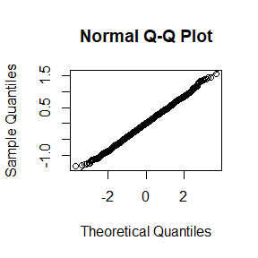

```r
qqnorm(residuals(linReg))
qqline(residuals(linReg))
```

From the Quantile-Quantile Plots,we can see the residuals of the model is Approximate normal distribution.

Use Germal-Rubin method to monitor convergence.

```r
bivarchain <- function(X,N){
  for (i in 2:N){
    x2 <- X[i-1,2]
    m1 <- mu1+rho*(x2-mu2)*sigma1/sigma2
    X[i,1] <- rnorm(1,m1,s1)
    x1 <- X[i,1]
    m2 <- mu2+rho*(x1-mu1)*sigma2/sigma1
    X[i,2] <- rnorm(1,m2,s2)
  }
  return(X)
}

G.R <- function(B) {
  B <- as.matrix(B)
  n <- ncol(B)
  k <- nrow(B)

  B.means <- rowMeans(B)
  Z <- n * var(B.means)
  B.w <- apply(B, 1, "var")
  W <- mean(B.w)
  v.hat <- W*(n-1)/n + (Z/n)
  r.hat <- v.hat / W
  return(r.hat)
}
```

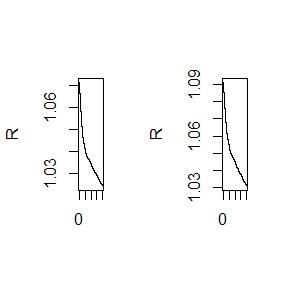

```r
N <- 5000; burn <- 1000; X <- matrix(0,N,2)
k <- 4 #number of chains to generate
s1 <- sqrt(1-rho^2)*sigma1;s2 <- sqrt(1-rho^2)*sigma2
n <- 5000       #length of chains
b <- 1000        #burn-in length

set.seed(123)
X1 <- matrix(0,N,2)
mu1 <- mu2 <- c(-5,-1,1,5)
x1 <-y1 <- matrix(0,4,N)

for(i in 1:4){
  X1[1,] <- c(mu1[i], mu2[i])
  X1 <- bivarchain(X1,N)
  x1[i,] <- X1[,1]
  y1[i,] <- X1[,2]
}

B1 <- t(apply(x1, 1, cumsum))
B2 <- t(apply(y1, 1, cumsum))
for(i in 1:nrow(B1)){
  B1[i,] <- B1[i,]/(1:ncol(B1))
}
for(i in 1:nrow(B2)){
  B2[i,] <- B2[i,]/(1:ncol(B2))
}

rhatx <- rhaty <-rep(0,N)
for(j in b:N){
  rhatx[j] <- G.R(B1[,1:j])
  rhaty[j] <- G.R(B2[,1:j])
}
par(mfrow=c(1,2))
plot(rhatx[b:N], type="l", xlab="", ylab="R")
plot(rhaty[b:N], type="l", xlab="", ylab="R")
```

## Question22

Test intermediary effect:
$$H_0:\alpha
\beta=0 \quad VS \quad H_a:\alpha \beta \neq 0$$

### Answer22

Consider the model:
$$M = a_M + \alpha X +
e_M$$
$$Y = a_Y + \beta M+ \gamma X +
e_Y$$

Suppose $X \sim N(0,1) ,e_M \sim N(0,1),e_Y \sim N(0,1),a_M=1,a_Y=1,\gamma=1,a_M=1,a_Y=1$

The test statistics is
$$T=\frac{\hat{\alpha}\hat{\beta}}{\hat{se}(\hat{\alpha}\hat{\beta})}=\frac{\hat{\alpha}\hat{\beta}}{\sqrt{\hat{\alpha}^2\hat{s}_\beta^2+\hat{\beta}^2\hat{s}_\alpha^2}}$$

```r
# generate sample
generateSample <- function(n,alpha,beta){
  X <- rnorm(n,0,1)
  gamma <-a_M<-a_Y<- 1;
  M <- a_M+alpha*X+rnorm(n)
  Y <- a_Y+beta*M+gamma*X+rnorm(n)
  return(list(X,M,Y))
}
```

```r
# The function of test statistics computation
Ttest <- function(X,M,Y){
  fit1 <- summary(lm(M~X))
  fit2 <- summary(lm(Y~X+M))
  a <- fit1$coefficients[2,1]
  sea <- fit1$coefficients[2,2]
  b <- fit2$coefficients[3,1]
  seb <- fit2$coefficients[3,2]
  return(a*b/((a*seb)^2+(b*sea)^2)^0.5)
}
```

```r
Imptest <- function(N,n,X,M,Y,T0){
  T1 <- T2 <- T3 <- numeric(N)
  # Condition 1
  for(i in 1:N){
    n1 <- sample(1:n, size=n, replace=FALSE)
    n2 <- sample(1:n, size=n, replace=FALSE)
    X1 <- X[n1];M1 <- M[n2];Y1 <- Y[n2]
    T1[i] <- Ttest(X1,M1,Y1)
  }
  # Condition 2
  for(i in 1:N){
    n1 <- sample(1:n, size = n, replace = FALSE)
    n2 <- sample(1:n, size = n, replace = FALSE)
    X2 <- X[n1];M2 <- M[n1];Y2 <- Y[n2]
    T2[i] <- Ttest(X2,M2,Y2)
  }
  # Condition 3
  for(i in 1:N){
    n1 <- sample(1:n, size = n, replace = FALSE)
    n2 <- sample(1:n, size = n, replace = FALSE)
    M3 <- M[n1];X3 <- X[n2];Y3 <- Y[n2]
    T3[i] <- Ttest(X3,M3,Y3)
  }
  # The p-value of Condition1
  p1 <- mean(abs(c(T0,T1))>abs(T0))
  # The p-value of Condition2
  p2 <- mean(abs(c(T0,T2))>abs(T0))
  # The p-value of Condition3
  p3 <- mean(abs(c(T0,T3))>abs(T0))
  return(c(p1,p2,p3))
}

N <- 1000 # The number of simulation
n <- 100 # The number of random sample
T0 <- numeric(3)
p <- matrix(0,3,3)
# The real values of parameters
alpha <- c(0,0,1);beta <- c(0,1,0)

for(i in 1:3){
  result <- generateSample(n,alpha[i],beta[i])
  X <- result[[1]]
  M <- result[[2]]
  Y <- result[[3]]
  # The original value of test statistics
  T0[i] <- Ttest(X,M,Y)
  p[i,] <- Imptest(N,n,X,M,Y,T0[i])
}
```

The output is show bellow:

```r
colnames(p) <- c("Condition 1","Condition 2","Condition 3")
rownames(p) <- c("alpha=0,beta=0","alpha=0,beta=1","alpha=1,beta=0")
p
```

```
##                Condition 1 Condition 2 Condition 3
## alpha=0,beta=0  0.47252747   0.1978022   0.1928072
## alpha=0,beta=1  0.02197802   0.0000000   0.0000000
## alpha=1,beta=0  0.83916084   0.8621379   0.7172827
```

## Question23

Consider the model $P(Y=1|X_1,X_2,X_3)=expit(a+b_1x_1+b_2x_2+b_3x_3),X_1 \sim Possion(1),X_2 \sim Exp(1),X_3 \sim B(1,0.5)$  
(1)Write a function to realize the above functions,and its input values is $N,b_1,b_2,b_3,f_0$, the output is alpha.  
(2)Call this function, and the input value is$N=10^6,b_1=0,b_2=1,b_3=-1,f_0=0.1,0.01,0.001,0.0001$  
(3)Plot $f_0 vs alpha$ Scatter plot.

### Answer23

```r
solveAlpha <- function(N,b1,b2,b3,f0){
  g <- function(alpha){
    tmp <- exp(-alpha-b1*x1-b2*x2-b3*x3)
    p <- 1/(1+tmp)
    mean(p) - f0
  }
  a <- -10
  b <- 10
  while (g(a)>0) {
    a <- a*10
  }
  while (g(b)<0) {
    b <- b*10
  }
  solution <- uniroot(g,c(a,b))
  return(solution$root)
}
```

```r
N <- 1e6;b1<-0;b2<-1;b3<--1
f0 <- c(0.1,0.01,0.001,0.0001)
x1 <- rpois(N,1);x2<-rexp(N);x3 <- sample(0:1,N,replace=TRUE)
alphaPred <- rep(0,length(f0))
for (i in 1:length(f0)) {
  alphaPred[i] <- solveAlpha(N,b1,b2,b3,f0[i])
}
alphaPred
```

```
## [1]  -3.166632  -6.070338  -8.704527 -11.224159
```

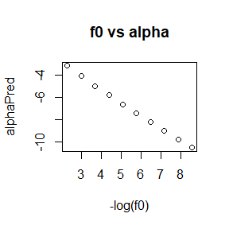

```r
f0<-rep(0,10)
f0[1] <- 0.1
alphaPred <- rep(0,10)
for (i in 2:10) {
  f0[i] <-f0[i-1]/2
}
for (i in 1:length(f0)) {
  alphaPred[i] <- solveAlpha(N,b1,b2,b3,f0[i])
}
plot(-log(f0),alphaPred,main='f0 vs alpha')
```

## Question24

Suppose $X_1,...,X_n \sim Exp(\lambda)$.Due to some reason,we can only know that $X_i$ falls in a certain interval($u_i,v_i$),and $u_i,v_i$ are two known non random constant.This data is called interval deletion data.  
(1) Try to directly maximize the likelihood function of observation data and the MLE of $\lambda$ to be solved by EM algorithm respectively, and prove that they are equal.  
(2)Suppose the observed data of $(u_i,v_i),i=1,...,n(=10)$ is (11,12),(8,9),(27,28),(13,14),(16,17),(0,1),(23,24),(10,11),(24,25),(2,3) .Try to program the above two algorithms separately to obtain the MLE numerical solution of $\lambda$

### Answer24

The likelihood function of the observed data is :

$$\begin{align}
L(\lambda) =& \prod_{i=1}^n P_{\lambda}(u_i \leq X_i \leq v_i)\\
=& \prod_{i=1}^n \int_{u_i}^{v_i} \lambda e^{-\lambda x}dx \\
=& \prod_{i=1}^n (e^{-\lambda u_i }-e^{-\lambda v_i}) \\
\end{align}$$
$$\frac{ \partial }{ \partial
\lambda } lnL(\lambda)= 0 \\
\sum_{i=1}^n \frac{v_ie^{-\lambda v_i}-u_ie^{-\lambda u_i}}{e^{-\lambda
u_i }-e^{-\lambda v_i}} = 0$$
EM algorithm:
$$l_c(\lambda) =
\sum_{i=1}^n logf_{\lambda}(x_i) = nlog\lambda - \lambda
\sum_{i=1}^nx_i$$
E-step:
$$\begin{align}
&E_{\hat \lambda_0}(l_c(\lambda)|X_i \in(u_i,v_i),i=1,...,n ) \\
=& nlog\lambda - \lambda\sum_{i=1}^n E_{\hat \lambda_0}(X_i|X_i \in
(u_i,v_i))\\
=& nlog\lambda - \lambda\sum_{i=1}^n
(\frac{1}{\hat{\lambda}_0}+\frac{u_{i} e^{-\hat{\lambda}_0 u_{i}}-v_{i}
e^{-\hat{\lambda}_0 v_{i}}}{e^{-\hat{\lambda}_0
u_{i}}-e^{-\hat{\lambda}_0 v_{i}}}) \\
= &nlog(\lambda) - \lambda \sum_{i=1}^n \hat X_i^{(1)}
\end{align}$$
M-step : Maximize new logarithmic likelihood function $E_{\hat \lambda_0}(l_c(\lambda)|X_i \in(u_i,v_i),i=1,...,n )=nlog(\lambda) - \lambda \sum_{i=1}^n \hat X_i^{(1)}$, where $\hat X_i^{(1)}=\frac{1}{\hat{\lambda}_0}+\frac{u_{i} e^{-\hat{\lambda}_0 u_{i}}-v_{i} e^{-\hat{\lambda}_0 v_{i}}}{e^{-\hat{\lambda}_0 u_{i}}-e^{-\hat{\lambda}_0 v_{i}}}$ . So $\hat \lambda_1 = \frac{n}{\sum_{i=1}^n \hat X_i^{(1)}}$ E-step and M-step are staggered until the algorithm converges. If the algorithm converges, the $\hat{\lambda}^{(\infty)}$ is
$$\hat{\lambda}^{(\infty)}=\frac{n}{\sum_{i=1}^{n}\left(\frac{1}{\hat{\lambda}^{(\infty)}}+\frac{u_{i}
e^{-\hat{\lambda}(\infty)} u_{i}-v_{i} e^{-\hat{\lambda}(\infty)}
v_{i}}{e^{-\hat{\lambda}(\infty)} u_{i}-e^{-\hat{\lambda}(\infty)}
v_{i}}\right)}$$
so $\hat{\lambda}^{(\infty)}$ satisfy the equation
$$\frac{u_{i}
e^{-\hat{\lambda}(\infty)} u_{i}-v_{i} e^{-\hat{\lambda}(\infty)}
v_{i}}{e^{-\hat{\lambda}(\infty)} u_{i}-e^{-\hat{\lambda}(\infty)}
v_{i}}=0$$
which is the same when we directly maximize the likelihood function.

```r
dt <- matrix(c(11,12,8,9,27,28,13,14,16,17,0,1,23,24,10,11,24,25,2,3),nrow = 10,ncol=2,byrow = TRUE)
```

```r
lkhood <- function(lambda){
  sm <- 0
  for (i in 1:nrow(dt)) {
    sm <- sm + (dt[i,1]*exp(-lambda*dt[i,1]) - dt[i,2]*exp(-lambda*dt[i,2]))/(exp(-lambda*dt[i,1]) - exp(-lambda*dt[i,2]))
  }
  sm
}
lambdaM <- uniroot(lkhood,c(0.1,0.05))
lambdaM$root
```

```
## [1] 0.07197522
```

```r
EMAlgorithm <- function(dt,lambda){
  x_hat <- rep(0,nrow(dt))
  for (i in 1:nrow(dt)) {
    x_hat[i] <- 1/lambda + (dt[i,1]*exp(-lambda*dt[i,1]) - dt[i,2]*exp(-lambda*dt[i,2]))/(exp(-lambda*dt[i,1]) - exp(-lambda*dt[i,2]))
  }
  return(nrow(dt)/sum(x_hat))
}
```

```r
eps <- 1e-4
lambda0 <- 1
lambda1<- EMAlgorithm(dt,lambda0)
while (abs(lambda1-lambda0)>eps) {
  lambda0 <- lambda1
  lambda1 <- EMAlgorithm(dt,lambda0)
}
lambda1
```

```
## [1] 0.0719735
```

## Question25

Why do you need to use unlist() to convert a list to an atomic vector? Why doesn’t as.vector() work?

### Answer25

The elements in lists can be heterogeneous. It can be any type,including list,vector,matrix and so on. So before convert a list to an atomic vector , it need to be unlisted first . A list is already a vector , so if we use as.vector() , it can’t convert the list to an atomic vector.

```r
a <- list(1,2,list(4,5))
b <- c(unlist(a))
b
```

```
## [1] 1 2 4 5
```

```r
as.vector(a)
```

```
## [[1]]
## [1] 1
##
## [[2]]
## [1] 2
##
## [[3]]
## [[3]][[1]]
## [1] 4
##
## [[3]][[2]]
## [1] 5
```

## Question26

why is 1 == ‘1’ true ? Why is -1 < FALSE true ? Why is ‘one’ < 2 false?

### Answer26

Because when we use operator-functions , the arguments will be coerced to a common type . So 1 will be coerced to ‘1’;FALSE will be represented as 0; 2 will be coerced to ‘2’(and numbers precede letters in lexicographic order).

```r
c(1 == '1',-1<FALSE,'one' < 2)
```

```
## [1]  TRUE  TRUE FALSE
```

## Question27

What does dim() return when applied to a vector?

### Answer27

dim() will return NULL when applied to a 1d vector.

```r
dim(c(1,2,4,5))
```

[output not shown]

## Question28

If is.matrix(x) is TRUE,what will is.array(x) return?

### Answer28

It will also return TRUE.

```r
ma <- matrix(1:12,3,4)
is.matrix(ma)
```

```
## [1] TRUE
```

```r
is.array(ma)
```

```
## [1] TRUE
```

## Question29

What attribute does a data frame possess?

### Answer29

names , class , row.names We can use attributes() function to test.

```r
df <- data.frame(col1 <- 1:3,col2=c('x','y','z'))
attributes(df)
```

```
## $names
## [1] "col1....1.3" "col2"
##
## $class
## [1] "data.frame"
##
## $row.names
## [1] 1 2 3
```

## Question30

Can you have a data frame with 0 rows?What about 0 columns?

### Answer30

Yes, we can create such data frame.

```r
data.frame(a=c(),b=character())
```

```
## [1] b
## <0 rows> (or 0-length row.names)
```

```r
data.frame(row.names = 1:5)
```

```
## data frame with 0 columns and 5 rows
```

```r
data.frame()
```

```
## data frame with 0 columns and 0 rows
```

## Question31

The function below scales a vector so it falls in the range [0,1]. How would you apply it to every column of a data frame? How would you apply it to every numeric column in a data frame?  
scale01 <- function(x) {  
rng <- range(x, na.rm = TRUE)  
(x - rng[1]) / (rng[2] - rng[1])  
}

### Answer31

We can check whether the input is a number through if clause.

```r
remove(list = ls())
scale01 <- function(x) {
  rng <- range(x, na.rm = TRUE)
  (x - rng[1]) / (rng[2] - rng[1])
}
```

```r
data.frame(lapply(mtcars, function(x) if( is.numeric(x)) round(scale01(x),4) else x))
```

```
##       mpg cyl   disp     hp   drat     wt   qsec vs am gear   carb
## 1  0.4511 0.5 0.2218 0.2049 0.5253 0.2830 0.2333  0  1  0.5 0.4286
## 2  0.4511 0.5 0.2218 0.2049 0.5253 0.3482 0.3000  0  1  0.5 0.4286
## 3  0.5277 0.0 0.0920 0.1449 0.5023 0.2063 0.4893  1  1  0.5 0.0000
## 4  0.4681 0.5 0.4662 0.2049 0.1475 0.4352 0.5881  1  0  0.0 0.0000
## 5  0.3532 1.0 0.7206 0.4346 0.1797 0.4927 0.3000  0  0  0.0 0.1429
## 6  0.3277 0.5 0.3839 0.1873 0.0000 0.4978 0.6810  1  0  0.0 0.0000
## 7  0.1660 1.0 0.7206 0.6820 0.2074 0.5260 0.1595  0  0  0.0 0.4286
## 8  0.5957 0.0 0.1886 0.0353 0.4286 0.4288 0.6548  1  0  0.5 0.1429
## 9  0.5277 0.0 0.1739 0.1519 0.5346 0.4186 1.0000  1  0  0.5 0.1429
## 10 0.3745 0.5 0.2407 0.2509 0.5346 0.4927 0.4524  1  0  0.5 0.4286
## 11 0.3149 0.5 0.2407 0.2509 0.5346 0.4927 0.5238  1  0  0.5 0.4286
## 12 0.2553 1.0 0.5106 0.4523 0.1429 0.6538 0.3452  0  0  0.0 0.2857
## 13 0.2936 1.0 0.5106 0.4523 0.1429 0.5669 0.3690  0  0  0.0 0.2857
## 14 0.2043 1.0 0.5106 0.4523 0.1429 0.5796 0.4167  0  0  0.0 0.2857
```

[output cut: 18 more lines]

## Question32

Use vapply() to:  
a) Compute the standard deviation of every column in a numeric data frame.  
b) Compute the standard deviation of every numeric column in a mixed data frame. (Hint: you’ll need to use vapply() twice.)

### Answer32

1. The dataset mtcars is a numeric data frame.

```r
head(mtcars)
```

```
##                    mpg cyl disp  hp drat    wt  qsec vs am gear carb
## Mazda RX4         21.0   6  160 110 3.90 2.620 16.46  0  1    4    4
## Mazda RX4 Wag     21.0   6  160 110 3.90 2.875 17.02  0  1    4    4
## Datsun 710        22.8   4  108  93 3.85 2.320 18.61  1  1    4    1
## Hornet 4 Drive    21.4   6  258 110 3.08 3.215 19.44  1  0    3    1
## Hornet Sportabout 18.7   8  360 175 3.15 3.440 17.02  0  0    3    2
## Valiant           18.1   6  225 105 2.76 3.460 20.22  1  0    3    1
```

```r
vapply(mtcars, sd, numeric(1))
```

```
##         mpg         cyl        disp          hp        drat          wt
##   6.0269481   1.7859216 123.9386938  68.5628685   0.5346787   0.9784574
##        qsec          vs          am        gear        carb
##   1.7869432   0.5040161   0.4989909   0.7378041   1.6152000
```

2. The dataset iris is a mixed data fame.

```r
head(iris)
```

```
##   Sepal.Length Sepal.Width Petal.Length Petal.Width Species
## 1          5.1         3.5          1.4         0.2  setosa
## 2          4.9         3.0          1.4         0.2  setosa
## 3          4.7         3.2          1.3         0.2  setosa
## 4          4.6         3.1          1.5         0.2  setosa
## 5          5.0         3.6          1.4         0.2  setosa
## 6          5.4         3.9          1.7         0.4  setosa
```

```r
vapply(iris[vapply(iris,is.numeric,logical(1))],sd,numeric(1))
```

```
## Sepal.Length  Sepal.Width Petal.Length  Petal.Width
##    0.8280661    0.4358663    1.7652982    0.7622377
```

## Question33

Implement a Gibbs sampler to generate a bivariate normal chain (Xt, Yt) with zero means, unit standard deviations, and correlation 0.9.  
(1)Write an Rcpp function.  
(2)Compare the corresponding generated random numbers with pure R language using the function “qqplot”.  
(3)Compare the computation time of the two functions with the function “microbenchmark”.

### Answer33

The target distribution is bivariate normal: $\left(X_{1}, X_{2}\right) \sim N\left(\mu_{1}, \mu_{2}, \sigma_{1}^{2}, \sigma_{2}^{2}, \rho\right)$ .
Conditional distributions $f\left(x_{1} \mid x_{2}\right) and f\left(x_{2} \mid x_{1}\right)$ :
$$\left(X_{1} \mid X_{2}\right) \sim
N\left(\mu_{1}+\rho \sigma_{1} /
\sigma_{2}\left(x_{2}-\mu_{2}\right),\left(1-\rho^{2}\right)
\sigma_{1}^{2}\right) \\
\left(X_{2} \mid X_{1}\right) \sim N\left(\mu_{2}+\rho \sigma_{2} /
\sigma_{1}\left(x_{1}-\mu_{1}\right),\left(1-\rho^{2}\right)
\sigma_{2}^{2}\right)$$

From the question ,we know that $\mu_1=\mu_2=0,\sigma_1^2=\sigma_2^2=1,\rho=0.9$. I set the length of chain is N=5000,and burn-in length is 1000.

```r
library(Rcpp)
cppFunction('NumericMatrix gibbsC(int N){
    NumericMatrix X(N,2);

    double mu1 = 0,mu2=0;
    double sigma1= 1,sigma2 = 1;
    double rho = 0.9;
    double s1 = sqrt(1-rho*rho)*sigma1;
    double s2 = sqrt(1-rho*rho)*sigma1;

    X(0,0) = 0;
    X(0,1) = 0;
    for (int i = 1; i < N; i++)
    {
        for (int j = 0; j < 2; j++)
        {
            double x2 = X(i - 1, 1);
            double m1 = mu1 + rho * (x2 - mu2) * sigma1 / sigma2;
            X(i,0) = R::rnorm(m1,s1);
            double x1 = X(i - 1, 0);
            double m2 = mu1 + rho * (x2 - mu2) * sigma1 / sigma2;
            X(i,1) = R::rnorm(m2,s2);
        }
    }
    return X;
}')
```

```r
set.seed(20221118)
GibbsR <- function(N){
  N<-N
  X <- matrix(0,N,2)

  rho <- 0
  mu1 <-mu2<-0;
  sigma1 <-sigma2<-1
  s1 <- s2<- sqrt(1-rho^2)*sigma1

  X[1,] <- c(mu1,mu2)  #initialize
  for (i in 2:N) {
    x2 <- X[i-1,2]
    m1 <- mu1 + rho*(x2-mu2)*sigma1/sigma2
    X[i,1] <- rnorm(1,m1,s1)
    x1 <- X[i,1]
    m2 <- mu2 + rho*(x1-mu1)*sigma2/sigma1
    X[i,2] <- rnorm(1,m2,s2)
  }
  return(X)
}
```

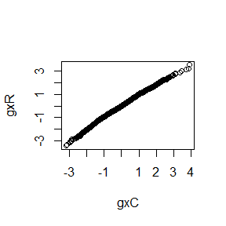

```r
burn <- 1000
gxC <- gibbsC(5000)[(burn+1):5000,1]
gxR <- GibbsR(5000)[(burn+1):5000,1]
qqplot(gxC,gxR)
```

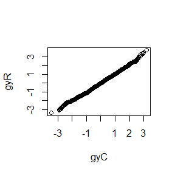

```r
burn <- 1000
gyC <- gibbsC(5000)[(burn+1):5000,2]
gyR <- GibbsR(5000)[(burn+1):5000,2]
qqplot(gyC,gyR)
```

```r
library(microbenchmark)
ts <- microbenchmark(gibbR = GibbsR(1000),gibbc = gibbsC(1000))
summary(ts)[,c(1,3,5,6)]
```

```
##    expr       lq    median       uq
## 1 gibbR 2925.351 3040.5510 3489.452
## 2 gibbc  175.551  179.4005  184.601
```